# Dataset #2: Movie Ratings

# Load the Data

```python
import numpy as np
import pandas as pd

import warnings
warnings.simplefilter('ignore', DeprecationWarning)

# dataset
datatrain = pd.read_csv('/Users/WeikangFan/Desktop/Movies_train.csv')
datatest = pd.read_csv('/Users/WeikangFan/Desktop/Movies_test.csv')
```

# Pre-Process the Movies Dataset

```python
%load_ext rmagic
import rpy2 as Rpy
```

```
The rmagic extension is already loaded. To reload it, use:
  %reload_ext rmagic
```

```python
%%R
train <- read.csv("Movies_train.csv")
sort <- sort(train$Length, decreasing = TRUE)
sort[1:50]
```

```
 [1] 5220 2880 1100  873  647  566  555  501  485  480  480  418  417  410  407
[16]  402  399  390  390  360  358  358  321  320  320  316  316  315  312  311
[31]  306  302  301  300  300  300  300  299  298  294  293  288  288  285  285
[46]  285  285  279  278  278
```

We could find that only a very small proportion of the training set observations (33 observations in total) have Length values larger than 300.

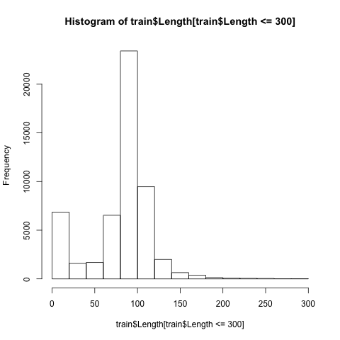

```python
%%R
hist(train$Length[train$Length <= 300])
```

From the histogram above we could find that Length values between 200 and 300 are rare too.

```python
%%R
length(train$Length[train$Length <= 200])/length(train$Length)
```

```
[1] 0.9958428
```

Length values no more than 200 take more than 99% of the whole sample. I decide to use the observaions with Length no more than 200 to train the classifier, so we can avoid the effects of some huge outliers.

Moreover, I use the mean value to substitute the NAs in Budget, and use the logs of Year, Length, Budget, and Votes intead of their original values.

```python
datatrain = datatrain.loc[datatrain['Length'] <= 200]

from numpy import log1p
datatrain['Year'] = [log1p(max(datatrain['Year']) - i) for i in datatrain['Year'] ]
datatrain['Budget'] = datatrain['Budget'].fillna(datatrain['Budget'].dropna().mean())
datatrain['Length'] = [log1p(i) for i in datatrain['Length'] ]
datatrain['Budget'] = [log1p(i) for i in datatrain['Budget'] ]
datatrain['Votes'] = [log1p(i) for i in datatrain['Votes'] ]

datatest['Year'] = [log1p(max(datatest['Year']) - i) for i in datatest['Year'] ]
datatest['Budget'] = datatest['Budget'].fillna(datatest['Budget'].dropna().mean())
datatest['Length'] = [log1p(i) for i in datatest['Length'] ]
datatest['Budget'] = [log1p(i) for i in datatest['Budget'] ]
datatest['Votes'] = [log1p(i) for i in datatest['Votes'] ]
```

# Variable Selection

The dataset has the following variables:

| **Title** | movie title |
| --- | --- |
| **Year** | year released |
| **Length** | length in minutes |
| **Budget** | production budget in US dollars (usually NA) |
| **Votes** | number of voting IMDB users |
| **R1** | approximate percentage of users voting for rating: 1 |
| **R2** | approximate percentage of users voting for rating: 2 |
| **R3** | approximate percentage of users voting for rating: 3 |
| **R4** | approximate percentage of users voting for rating: 4 |
| **R5** | approximate percentage of users voting for rating: 5 |
| **R6** | approximate percentage of users voting for rating: 6 |
| **R7** | approximate percentage of users voting for rating: 7 |
| **R8** | approximate percentage of users voting for rating: 8 |
| **R9** | approximate percentage of users voting for rating: 9 |
| **R10** | approximate percentage of users voting for rating: 10 |
| **MPAA** | MPAA parental guidance rating (blank, NC-17, PG, PG-13, R) |
| **Action** | 1 if Action, 0 otherwise |
| **Animation** | 1 if Animation, 0 otherwise |
| **Comedy** | 1 if Comedy, 0 otherwise |
| **Drama** | 1 if Drama, 0 otherwise |
| **Documentary** | 1 if Documentary, 0 otherwise |
| **Romance** | 1 if Romance, 0 otherwise |
| **Short** | 1 if Short Film, 0 otherwise |

Among those variables, Length is negatively correlated with Short: movies of higher Length has Short = 0, and movies of lower Length has Short = 1. The following correlation table computed by R agrees with my assumption.

```python
%%R
train <- read.csv("/Users/WeikangFan/Desktop/Movies_train.csv")
cor(train[,c('Length','Short')])
```

```
           Length      Short
Length  1.0000000 -0.6655172
Short  -0.6655172  1.0000000
```

And compared with the predictor set including MPAA, the predictor set without MPAA gives better prediction results. Title has no correlation with Rating, hence I finally decide to use all the variables except for Title, MPAA, and Short.

# Prediction: Use Random Forest

I have tried various methods and random forest definitely beats all the others.

#### Use random forest to train the classifier and make predictions

```python
x_train = datatrain.drop(["Rating", "Title", "Short", "MPAA"],1)
y_train = datatrain.Rating
x_test = datatest.drop(["Rating", "Title", "Short", "MPAA"],1)

# use Random Forest to predict
from sklearn.ensemble import RandomForestClassifier
np.random.seed(1234)
rf = RandomForestClassifier(n_estimators=500, max_features='auto').fit(x_train,y_train)
pred = rf.predict(x_test)
```

#### Write the result to a text file

```python
# Write results to a txt file
def two_digit_value(x):
    return ("%3.1f" % x)
    # return a value of the form X.Y, where X and Y are digits
output_str = "\n".join(map(two_digit_value, pred))
f = open('/Users/WeikangFan/Desktop/output-movie.txt', 'w')
f.write(output_str);
f.close()
```

The correction rate is 51.41% according to the mooshak.